# Bias Variance Tradeoff

SRM과 PA 기초

sonsungman https://sonsungman.github.io/SKKU-Preditive.m/  
10-03-2021

### 서론

SOA과정 중 SRM을 통해 학습하게 되는 다양한 머신러닝 모델과 통계이론들, PA를 통해 직접 R로 분석하여 커뮤니케이션 문서를 제작하는 경험은 계리사의 실무적인 업무를 경험하고 준비하는 좋은 과정이라 생각한다. SRM을 통해 여러가지 모델들을 학습하게 되는데 여러 교재들이 있지만 SOA측에서 제시하는 2권의 참고서적 중 ISLR(Introduction to Statistical Learning with Applications in R)에서 제시하는 개념 중 Bias Variance Tradeoff의 개념을 이 글에서 논해보고자 한다. 온라인 상 해당 서적의 PDF파일이 풀려 있어 관련 내용을 함께 제시한다.

### 트레이드 오프

트레이드 오프라는 단어는 우리의 현실을 잘 나타낸다. 우리가 현실에서 풀어내야하는 문제는 절대 이상향이 존재하지 않는다. 즉, 모든 조건을 만족시키는 완벽한 솔루션은 존재하지않는다는 의미. 우리는 몇가지의 조건 속에서 특정 조건에 관한 만족수준을 올리려 한다면 타 조건에 관하여서는 희생이 필요하다. 문제를 정의하는 단계는 이러한 조건들을 명확하게 인식하고 추상화 시키는 과정. 그 이후 문제에 관한 솔루션을 제시한다는 것은 이 조건들의 함수관계를 이해하며 우리가 직면하고 있는 현실을 인식하여 적정한 함수적 관계를 제시하는 것이라 본다. 우리에게 필요한 것은 문제의 정의하고 추상화 시키는 것, 현실을 이해하고 그에 맞는 해결책을 제시하는 것, 그리고 그에 관한 해결책을 도입했을 때에 변화하는 상황을 모니터링하며 우리가 잡아내지 못한 변수들, 급변하는 현실 상황, 결과에 관한 우리의 예측과 실제의 차이를 분석하여 반영해가는 것이다.

### 예를 들어 보자.

공적 연금의 개혁에 관하여서 문제는 2가지 변수의 함수 관계로 정리할 수 있다. 급여적정성과 지속가능성의 함수. 급여수준은 소득대체율로 표현되며 지속가능성은 적정한 보험료를 통한 기금이 고갈되지 않고 적정하게 유지될 수 있도록 하는 것으로 생각할 수 있다. 정치적 논제는 문제의 핵심을 다른 언어로 표현한 것에 불가하다. 공적 연금의 기능인 사회적 재분배와 규모의 경제를 활용한 높은 투자수익률 추구는 공적 연금의 필요성을 주장하는 근거이지 문제의 핵심은 아니다.

### Bias-Variance

머신 러닝의 목적은 트레이닝 데이터 셋 $x_{i1}, .... , x_{ik}$에 대해 $i = 1, ..., n$이고 각 $x_{i1}, .... , x_{ik}$ 에 대해 $y_{i}$가 존재할 때 실제 함수관계 $y_{i} = f(X) + \epsilon_{i}$에 대해 $\hat f$을 찾는 것이다. 이 때 MSE를 최소화하는 방법을 사용하는데 트레이닝 데이터에 대한 최소화 뿐 아니라 새로운 테스트 데이터에 대한 MSE도 최소화하는 것을 목적으로 한다.

Bias의 경우 모델을 간단하게(복잡하지 않게 flexible 하지 않게) 하였을 때, 그에 따른 가정이 잘못될 경우 발생 한다. 모델이 복잡할 수록 트레이닝 데이터에 적합되어 실제치와 모델에 의한 예측값의 차이가 적으므로 Bias는 0이 된다. Variance의 경우 트레이닝 데이터에 지나치게 fitting되어(매우 복잡, 높은 flexibility) 테스트 데이터에 대해 일반화되지 못하므로 발생하는 오류다. 트레이닝 데이터에 의해 학습한 모델에 새로운 데이터을 넣었을 때 산출되는 예측값의 변동성으로 생각할 수 있고 복잡한 모델일 수록 Variance는 커진다. 우리의 문제는 y에 관한 근사함수 $\hat f$를 찾는 것인데, 이 $\hat f$의 복잡성의 정도는 2가지 축 Bias와 Variance으로 표현된다. 이 두가지의 함수적 관계를 활용하여야 한다.

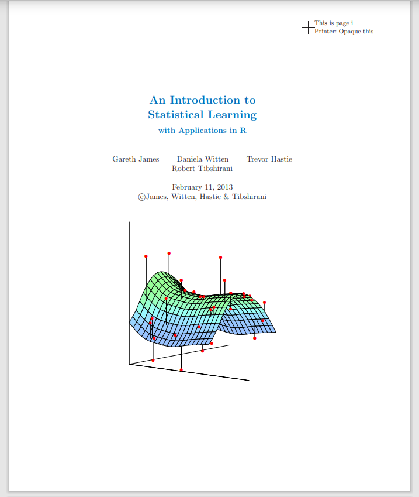

Figure 1: ISLR 관련 자료

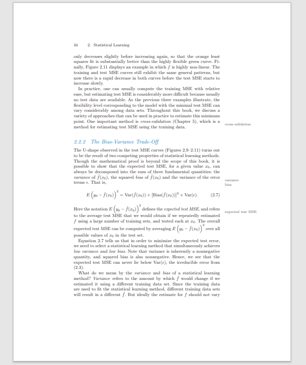

Figure 2: ISLR 관련 자료

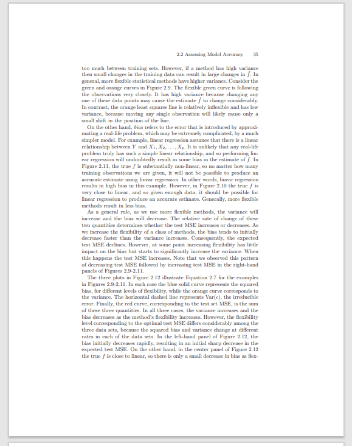

Figure 3: ISLR 관련 자료

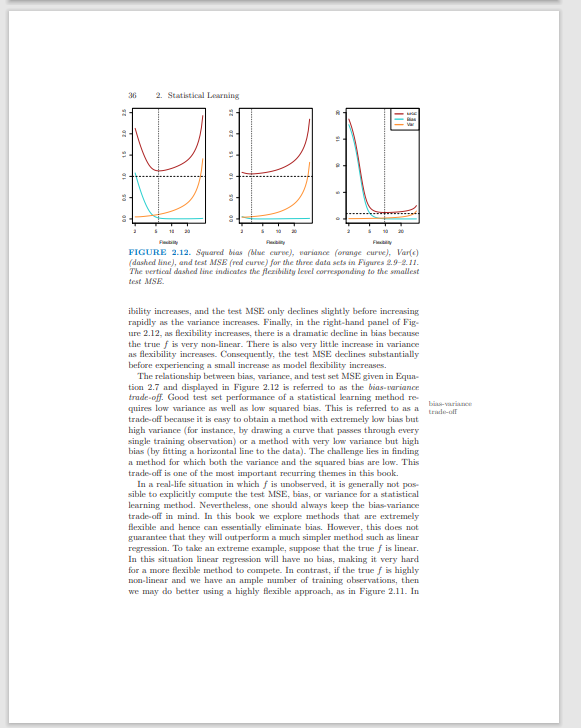

Figure 4: ISLR 관련 자료

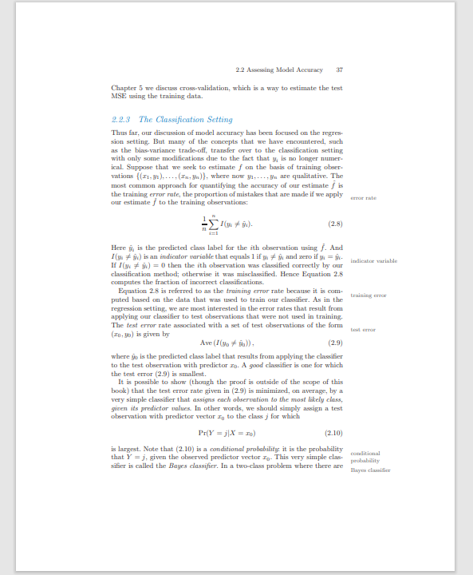

Figure 5: ISLR 관련 자료